# Лабораторная работа №4

Шубнякова Дарья, НКАбд-03-22

## Содержание

1. Цель
2. Теоретическое введение
3. Основные задачи
4. Процесс выполнения
5. Вывод
6. Список литературы

## Цель

Приобретение практических навыков взаимодействия пользователя с системой по- средством командной строки.

## Теоретическое введение

История ОС UNIX началась в 1969 году в одном из подразделений AT&T Bell Laboratories, когда на “малоиспользуемой” машине DEC PDP-7 Кен Томпсон (Ken Thompson), Деннис Ричи (Dennis Ritchie) и другие (прежде занимавшиеся созданием ОС Multics) начали работу над операционной системой, названной ими первоначально Unics (UNiplexed Information and Computing System).

## Основные задачи

1. Определите полное имя вашего домашнего каталога. Далее относительно этого каталога будут выполняться последующие упражнения.
2. Выполните следующие действия: 2.1. Перейдите в каталог /tmp. 2.2. Выведите на экран содержимое каталога /tmp. Для этого используйте команду ls с различными опциями. Поясните разницу в выводимой на экран информации. 2.3. Определите, есть ли в каталоге /var/spool подкаталог с именем cron? 2.4. Перейдите в Ваш домашний каталог и выведите на экран его содержимое. Определите, кто является владельцем файлов и подкаталогов?

## Основные задачи

3. Выполните следующие действия: 3.1. В домашнем каталоге создайте новый каталог с именем newdir. 3.2. В каталоге ~/newdir создайте новый каталог с именем morefun. 3.3. В домашнем каталоге создайте одной командой три новых каталога с именами letters, memos, misk. Затем удалите эти каталоги одной командой. 3.4. Попробуйте удалить ранее созданный каталог ~/newdir командой rm. Проверьте, был ли каталог удалён. 3.5. Удалите каталог ~/newdir/morefun из домашнего каталога. Проверьте, был ли каталог удалён.
4. С помощью команды man определите, какую опцию команды ls нужно использовать для просмотра содержимое не только указанного каталога, но и подкаталогов, входящих в него.

## Основные задачи

5. С помощью команды man определите набор опций команды ls, позволяющий отсортировать по времени последнего изменения выводимый список содержимого каталога с развёрнутым описанием файлов.
6. Используйте команду man для просмотра описания следующих команд: cd, pwd, mkdir, rmdir, rm. Поясните основные опции этих команд.
7. Используя информацию, полученную при помощи команды history, выполните модификацию и исполнение нескольких команд из буфера команд.

## Процесс выполнения

1. С помощью команды pwd узнаем полное имя домашнего каталога.

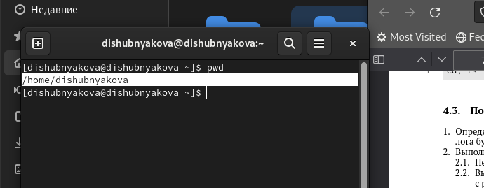

Название домашнего каталога

## Процесс выполнения

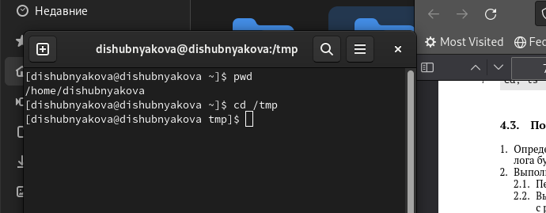

Перешли в нужный каталог

## Процесс выполнения

3. С помощью команды ls -a выводятся все файлы, включая скрытые.

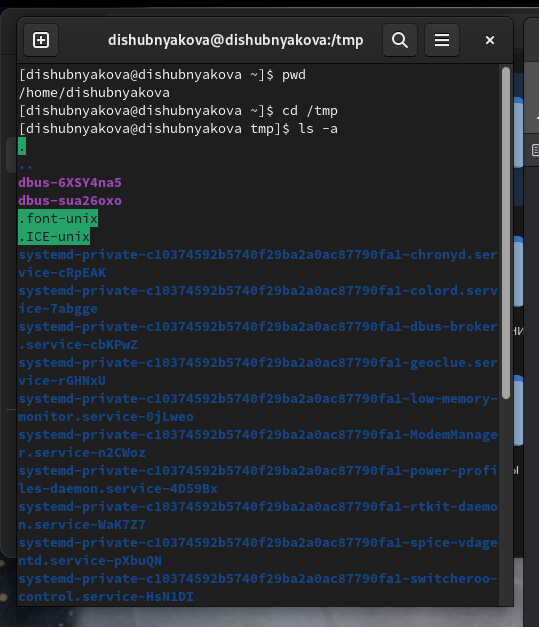

Реализация команды

## Процесс выполнения

4. Переходим в домашний каталог и с помощью команды ls -alF определяем, кто является владельцем файлов и подкаталогов.

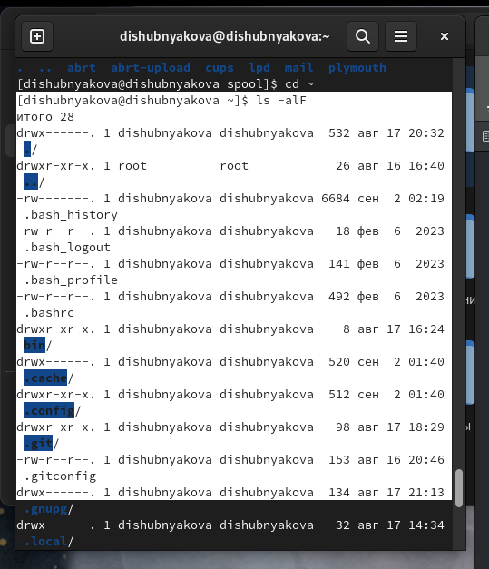

Реализация команды

## Процесс выполнения

5. Создаем папку newdir с помощью команды mkdir в домашнем каталоге.

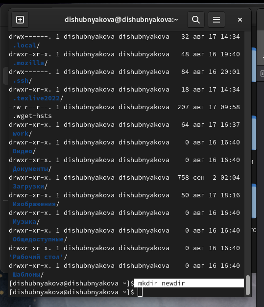

Реализация команды

## Процесс выполнения

6. С помощью команды rmdir удаляем эти созданные пустые каталоги.

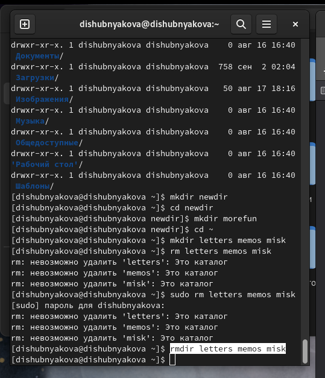

Реализация команды

## Процесс выполнения

7. С помощью команды history и специальной конструкции !<номер_команды>:s/<что_меняем>/<на_что_меняем> модифицируем одну из предыдущих команд.

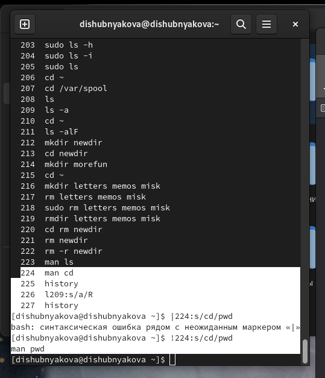

Реализация команды

## Процесс выполнения

8. С помощью команды history и конструкции !<номер_команды> можно повторить выполнение какой-либо команды. В моем случае я хотела повторить команду перехода в папку newdir, но мы помним. что удаляли ее и поэтому переход в этот каталог больше не осуществляется.

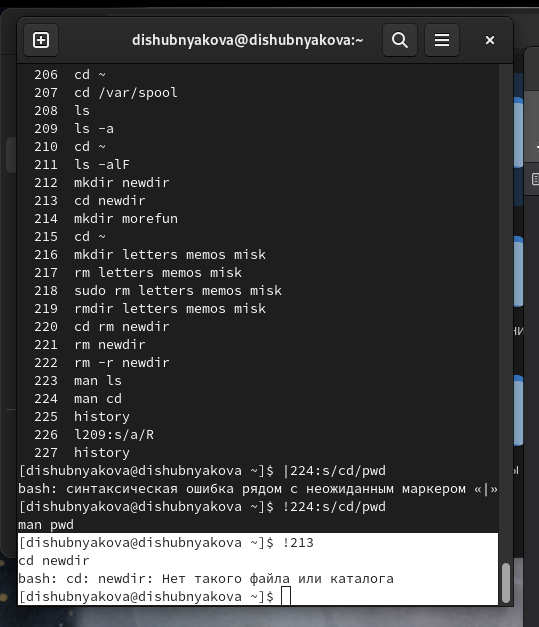

Реализация команды

## Вывод

Научились взаимодействовать с командной строкой в системе Unix. Изучили базовые команды и их основные опции.

## Список литературы

1. Dash P. Getting started with oracle vm virtualbox. Packt Publishing Ltd, 2013. 86 p.
2. Colvin H. Virtualbox: An ultimate guide book on virtualization with virtualbox. CreateSpace Independent Publishing Platform, 2015. 70 p.
3. van Vugt S. Red hat rhcsa/rhce 7 cert guide : Red hat enterprise linux 7 (ex200 and ex300). Pearson IT Certification, 2016. 1008 p.
4. Робачевский А., Немнюгин С., Стесик О. Операционная система unix. 2-е изд. Санкт-Петербург: БХВ-Петербург, 2010. 656 p.
5. Немет Э. et al. Unix и Linux: руководство системного администратора. 4-е изд. Вильямс, 2014. 1312 p.
6. Колисниченко Д.Н. Самоучитель системного администратора Linux. СПб.: БХВ-Петербург, 2011. 544 p.
7. Robbins A. Bash pocket reference. O’Reilly Media, 2016. 156 p.

Спасибо за внимание!